# Exploring Data

RAdelaide 2024

Author

Affiliation

Dr Stevie Pederson

Black Ochre Data Labs  
Telethon Kids Institute

Published

July 9, 2024

# Exploring Our Data

## Exploring Data

Now we have loaded some data into R

- What does it look like?
- Can we obtain summary tables?

. . .

We’ll start with some basic approaches $\rightarrow$ more sophisticated

## Basic Plotting

- `R` comes with some basic plotting capabilities
- Can be easy to quickly explore $\rightarrow$ difficult to tweak
- Later we’ll thoroughly explore `ggplot2`
  - Is now the gold standard for data visualisation

. . .

- `plot()` is useful for quick *x vs. y* plots
- `boxplot()` is also fairly intuitive

## Basic Plotting

- The values in any column can be obtained using `$`

```r
## Look at all of the odontoblast lengths
pigs$len
```

```
 [1]  4.2 11.5  7.3  5.8  6.4 10.0 11.2 11.2  5.2  7.0 16.5 16.5 15.2 17.3 22.5
[16] 17.3 13.6 14.5 18.8 15.5 23.6 18.5 33.9 25.5 26.4 32.5 26.7 21.5 23.3 29.5
[31] 15.2 21.5 17.6  9.7 14.5 10.0  8.2  9.4 16.5  9.7 19.7 23.3 23.6 26.4 20.0
[46] 25.2 25.8 21.2 14.5 27.3 25.5 26.4 22.4 24.5 24.8 30.9 26.4 27.3 29.4 23.0
```

- We’ll discuss in great (!!!) detail tomorrow

## Basic Plotting

- Passing this to `plot()` will plot the values in order

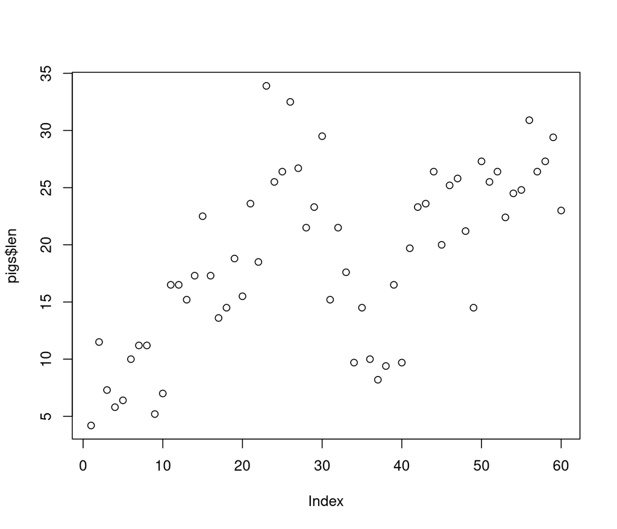

```r
plot(pigs$len)
```

- If we had another numeric value we could’ve compared in a classic x vs y

## Basic Boxplots

- To make a boxplot we can plot `len` as our response variable
  - Could take either `supp` or `dose` as the predictor
- R uses *formula syntax*
  - `len ~ supp` $\implies$ `len` **depends on** `supp`

```r
## Show length as being dependent on supp
boxplot(len ~ supp, data = pigs)
```

[output not shown]

. . .

- Try changing `supp` to `dose`

## Basic Boxplots

- We can show `len` as depending on both using `+`

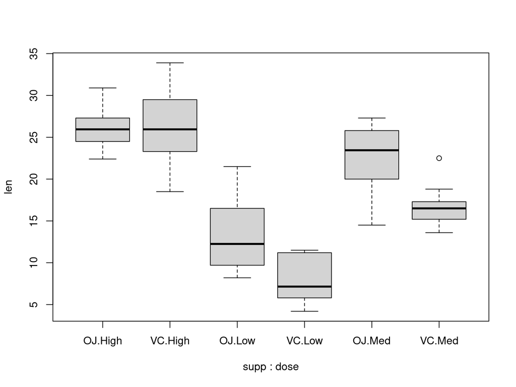

```r
## Show length as being dependent on
## both supp & dose
boxplot(len ~ supp + dose, data = pigs)
```

## Basic Plotting

- Many more options e.g. `hist()`

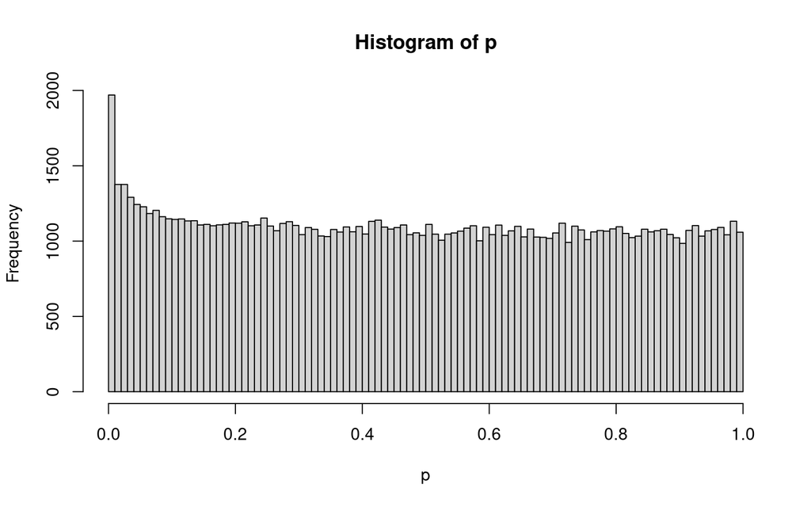

```r
p <- c(runif(1e5), rbeta(1e4, 0.5, 1))
hist(p, breaks = 100)
```

. . .

- `ggplot2` is generally superior

# Exploring Data Using `dplyr`

## Introducing `dplyr`

- `dplyr` is a core `tidyverse` package
  - Always loaded with `library(tidyverse)`
- Amazingly useful for
  - Exploring Data
  - Cleaning (i.e. tidying) Data
  - Modifying & Manipulating Data
  - Summarising Data
- Contains many *Excel-like* functions

## Sorting Data

- By default, `pigs` is in the order we loaded it
- Can we sort by `len`?

. . .

- The function `arrange()`

## Sorting Data

- Here we call the function `arrange()`
  - The `data.frame` is the first argument
  - Any of the column names can then be passed after this

```r
## Sort by length
arrange(pigs, len)
```

```
# A tibble: 60 × 3
     len supp  dose
   <dbl> <chr> <chr>
 1   4.2 VC    Low
 2   5.2 VC    Low
 3   5.8 VC    Low
 4   6.4 VC    Low
 5   7   VC    Low
 6   7.3 VC    Low
 7   8.2 OJ    Low
 8   9.4 OJ    Low
 9   9.7 OJ    Low
10   9.7 OJ    Low
# ℹ 50 more rows
```

## Sorting Data

- Have we changed the original object?

. . .

*Hint: To create an object in `R` we use `objectName <- data`*

## Sorting Data

- Sorting is done in increasing order by default
- To sort in descending order  
  $\implies$ wrap the column name inside the function `desc()`

```r
## Sort by length, in descending order
arrange(pigs, desc(len))
```

```
# A tibble: 60 × 3
     len supp  dose
   <dbl> <chr> <chr>
 1  33.9 VC    High
 2  32.5 VC    High
 3  30.9 OJ    High
 4  29.5 VC    High
 5  29.4 OJ    High
 6  27.3 OJ    Med
 7  27.3 OJ    High
 8  26.7 VC    High
 9  26.4 VC    High
10  26.4 OJ    Med
# ℹ 50 more rows
```

## Filtering Data

- `dplyr` also contains the function `filter()`

```r
## Just subset to the high dose
filter(pigs, dose == "High")
```

```
# A tibble: 20 × 3
     len supp  dose
   <dbl> <chr> <chr>
 1  23.6 VC    High
 2  18.5 VC    High
 3  33.9 VC    High
 4  25.5 VC    High
 5  26.4 VC    High
 6  32.5 VC    High
 7  26.7 VC    High
 8  21.5 VC    High
 9  23.3 VC    High
10  29.5 VC    High
11  25.5 OJ    High
12  26.4 OJ    High
13  22.4 OJ    High
14  24.5 OJ    High
15  24.8 OJ    High
16  30.9 OJ    High
17  26.4 OJ    High
18  27.3 OJ    High
19  29.4 OJ    High
20  23   OJ    High
```

## Filtering Data

- Behind the scenes a logical test has been applied
- Can only return the values `TRUE` or `FALSE`

```r
1:5 > 2
```

```
[1] FALSE FALSE  TRUE  TRUE  TRUE
```

. . .

- The symbol `==` applies the test *is equal to*

```r
1:5 == 2
```

```
[1] FALSE  TRUE FALSE FALSE FALSE
```

. . .

- The converse is `!=` $\implies$ *is NOT equal to*

```r
1:5 != 2
```

```
[1]  TRUE FALSE  TRUE  TRUE  TRUE
```

## Filtering Data

- We could *exclude* the high dose values instead

```r
filter(pigs, dose != "High")
```

```
# A tibble: 40 × 3
     len supp  dose
   <dbl> <chr> <chr>
 1   4.2 VC    Low
 2  11.5 VC    Low
 3   7.3 VC    Low
 4   5.8 VC    Low
 5   6.4 VC    Low
 6  10   VC    Low
 7  11.2 VC    Low
 8  11.2 VC    Low
 9   5.2 VC    Low
10   7   VC    Low
# ℹ 30 more rows
```

## Filtering Data

- Multiple filters can be separated by a comma

```r
filter(pigs, dose == "High", supp == "OJ")
```

```
# A tibble: 10 × 3
     len supp  dose
   <dbl> <chr> <chr>
 1  25.5 OJ    High
 2  26.4 OJ    High
 3  22.4 OJ    High
 4  24.5 OJ    High
 5  24.8 OJ    High
 6  30.9 OJ    High
 7  26.4 OJ    High
 8  27.3 OJ    High
 9  29.4 OJ    High
10  23   OJ    High
```

## Filtering Data

- Can also filter on numeric values

```r
filter(pigs, len > 20)
```

```
# A tibble: 28 × 3
     len supp  dose
   <dbl> <chr> <chr>
 1  22.5 VC    Med
 2  23.6 VC    High
 3  33.9 VC    High
 4  25.5 VC    High
 5  26.4 VC    High
 6  32.5 VC    High
 7  26.7 VC    High
 8  21.5 VC    High
 9  23.3 VC    High
10  29.5 VC    High
# ℹ 18 more rows
```

# Combining Functions

## Combining Functions

- Can we filter **then** sort?
  - Without modifying the original data?

. . .

- We need to pass the output of one function into the next

. . .

- Often referred to as *piping* data
  - Very familiar for those who know `bash` (`|`)

## Combining Functions

Two options in `R`

1. The native pipe `|>`
   - Introduced in R v4.1 (2021)
2. The *magrittr* pipe `%>%`
   - Introduced in the package `magrittr` (2014)

. . .

- Both behave similarly
- Code pre-2021 will always use `%>%`
- Code post-2021 *may use either*

## The package `magrittr`

[figure not shown]

The Treachery of Images, Rene Magritte, 1929

## The package `magrittr`

- I personally prefer `%>%` so we will use today
- `%>%` is loaded by `dplyr` *from* the package `magrittr`
  - The package implements some other useful functions
  - Beyond the scope of today (probably)

## Combining Functions

- Both `|>` and `%>%` take the output of one function  
  $\implies$ place it as the *first argument* of a second
- Like sticking a pipe on the output of one $\rightarrow$ connecting it to the input of another

Compare the pair

. . .

```r
arrange(pigs, len)
```

```
# A tibble: 60 × 3
     len supp  dose
   <dbl> <chr> <chr>
 1   4.2 VC    Low
 2   5.2 VC    Low
 3   5.8 VC    Low
 4   6.4 VC    Low
 5   7   VC    Low
 6   7.3 VC    Low
 7   8.2 OJ    Low
 8   9.4 OJ    Low
 9   9.7 OJ    Low
10   9.7 OJ    Low
# ℹ 50 more rows
```

```r
pigs %>% arrange(len)
```

```
# A tibble: 60 × 3
     len supp  dose
   <dbl> <chr> <chr>
 1   4.2 VC    Low
 2   5.2 VC    Low
 3   5.8 VC    Low
 4   6.4 VC    Low
 5   7   VC    Low
 6   7.3 VC    Low
 7   8.2 OJ    Low
 8   9.4 OJ    Low
 9   9.7 OJ    Low
10   9.7 OJ    Low
# ℹ 50 more rows
```

## Combining Functions

- Now we can join multiple functions together

```r
pigs %>%
  filter(supp == "OJ") %>%
  arrange(len)
```

. . .

1. Calling `pigs` returns the object `pigs`
2. We filter this input `filter(supp == "OJ")`
3. Arrange the filtered object by `arrange(len)`

## Combining Functions

Note how I wrote every function on a new line

```r
pigs %>%
  filter(supp == "OJ") %>%
  arrange(len)
```

. . .

- Makes every step clear to the reader
- Can easily comment a line out in the middle
  - Shortcut is `Ctrl/Cmd + Shift + C`
- RStudio will automatically indent
  - You can see where the steps start >$\implies$ where the process continues

## Adding Columns Using `mutate()`

- The function `mutate()` can be used to add columns
  - Can also modify existing columns

```r
pigs %>%
  arrange(len) %>%
  mutate(rank = rank(len))
```

```
# A tibble: 60 × 4
     len supp  dose   rank
   <dbl> <chr> <chr> <dbl>
 1   4.2 VC    Low     1
 2   5.2 VC    Low     2
 3   5.8 VC    Low     3
 4   6.4 VC    Low     4
 5   7   VC    Low     5
 6   7.3 VC    Low     6
 7   8.2 OJ    Low     7
 8   9.4 OJ    Low     8
 9   9.7 OJ    Low     9.5
10   9.7 OJ    Low     9.5
# ℹ 50 more rows
```

## Adding Columns Using `mutate()`

- Columns are added sequentially
- Can refer to them when adding any further columns

```r
pigs %>%
  mutate(
    rank = rank(len),
    quantile = rank / max(rank)
  )
```

```
# A tibble: 60 × 5
     len supp  dose   rank quantile
   <dbl> <chr> <chr> <dbl>    <dbl>
 1   4.2 VC    Low     1     0.0167
 2  11.5 VC    Low    15     0.25
 3   7.3 VC    Low     6     0.1
 4   5.8 VC    Low     3     0.05
 5   6.4 VC    Low     4     0.0667
 6  10   VC    Low    11.5   0.192
 7  11.2 VC    Low    13.5   0.225
 8  11.2 VC    Low    13.5   0.225
 9   5.2 VC    Low     2     0.0333
10   7   VC    Low     5     0.0833
# ℹ 50 more rows
```

When adding multiple columns $\implies$ each on a new line

## Choosing Rows

- `slice()` can be used to choose specific rows *by position*
  - Will never select rows beyond the range of the data
- `filter()` selects rows *by values*

```r
pigs %>%
  slice(1:5)
```

```
# A tibble: 5 × 3
    len supp  dose
  <dbl> <chr> <chr>
1   4.2 VC    Low
2  11.5 VC    Low
3   7.3 VC    Low
4   5.8 VC    Low
5   6.4 VC    Low
```

## Choosing Rows

- Can easily grab values for sorted data  
  $\implies$ the 5 with shortest odontoblasts

```r
pigs %>%
  arrange(len) %>%
  slice(1:5)
```

```
# A tibble: 5 × 3
    len supp  dose
  <dbl> <chr> <chr>
1   4.2 VC    Low
2   5.2 VC    Low
3   5.8 VC    Low
4   6.4 VC    Low
5   7   VC    Low
```

## Choosing Columns Using `select()`

- The function `select()` can be used to select specific columns
  - One of the “heavy-lifters” of `dpylr`

```r
pigs %>%
  select(len)
```

```
# A tibble: 60 × 1
     len
   <dbl>
 1   4.2
 2  11.5
 3   7.3
 4   5.8
 5   6.4
 6  10
 7  11.2
 8  11.2
 9   5.2
10   7
# ℹ 50 more rows
```

## Choosing Columns Using `select()`

- Very useful for reordering columns when creating tables

```r
pigs %>%
  select(supp, dose, len)
```

```
# A tibble: 60 × 3
   supp  dose    len
   <chr> <chr> <dbl>
 1 VC    Low     4.2
 2 VC    Low    11.5
 3 VC    Low     7.3
 4 VC    Low     5.8
 5 VC    Low     6.4
 6 VC    Low    10
 7 VC    Low    11.2
 8 VC    Low    11.2
 9 VC    Low     5.2
10 VC    Low     7
# ℹ 50 more rows
```

## Choosing Columns Using `select()`

- Remove columns by placing `-` before the name

```r
pigs %>%
  mutate(
    rank = rank(len),
    quantile = rank / max(rank)
  ) %>%
  select(-rank)
```

```
# A tibble: 60 × 4
     len supp  dose  quantile
   <dbl> <chr> <chr>    <dbl>
 1   4.2 VC    Low     0.0167
 2  11.5 VC    Low     0.25
 3   7.3 VC    Low     0.1
 4   5.8 VC    Low     0.05
 5   6.4 VC    Low     0.0667
 6  10   VC    Low     0.192
 7  11.2 VC    Low     0.225
 8  11.2 VC    Low     0.225
 9   5.2 VC    Low     0.0333
10   7   VC    Low     0.0833
# ℹ 50 more rows
```

## Choosing Columns Using `select()`

- Or we can just select everything *but* that column

```r
pigs %>%
  mutate(
    rank = rank(len),
    quantile = rank / max(rank)
  ) %>%
  select(supp, dose, len, quantile)
```

```
# A tibble: 60 × 4
   supp  dose    len quantile
   <chr> <chr> <dbl>    <dbl>
 1 VC    Low     4.2   0.0167
 2 VC    Low    11.5   0.25
 3 VC    Low     7.3   0.1
 4 VC    Low     5.8   0.05
 5 VC    Low     6.4   0.0667
 6 VC    Low    10     0.192
 7 VC    Low    11.2   0.225
 8 VC    Low    11.2   0.225
 9 VC    Low     5.2   0.0333
10 VC    Low     7     0.0833
# ℹ 50 more rows
```

## Using Helpers

- The package `tidyselect` provides helpers to select by pattern
- `starts_with()`, `ends_with()`, `contains()`, `everything()`

```r
pigs %>%
  select(starts_with("d"))
```

```
# A tibble: 60 × 1
   dose
   <chr>
 1 Low
 2 Low
 3 Low
 4 Low
 5 Low
 6 Low
 7 Low
 8 Low
 9 Low
10 Low
# ℹ 50 more rows
```

## Using Helpers

```r
pigs %>%
  select(ends_with("n"))
```

```
# A tibble: 60 × 1
     len
   <dbl>
 1   4.2
 2  11.5
 3   7.3
 4   5.8
 5   6.4
 6  10
 7  11.2
 8  11.2
 9   5.2
10   7
# ℹ 50 more rows
```

## Using Helpers

```r
pigs %>%
  select(contains("e"))
```

```
# A tibble: 60 × 2
     len dose
   <dbl> <chr>
 1   4.2 Low
 2  11.5 Low
 3   7.3 Low
 4   5.8 Low
 5   6.4 Low
 6  10   Low
 7  11.2 Low
 8  11.2 Low
 9   5.2 Low
10   7   Low
# ℹ 50 more rows
```

## Using Helpers

- `everything()` is great for putting columns first then the rest…

```r
pigs %>%
  mutate(
    rank = rank(len),
    quantile = rank / max(rank)
  ) %>%
  select(supp, dose, everything())
```

```
# A tibble: 60 × 5
   supp  dose    len  rank quantile
   <chr> <chr> <dbl> <dbl>    <dbl>
 1 VC    Low     4.2   1     0.0167
 2 VC    Low    11.5  15     0.25
 3 VC    Low     7.3   6     0.1
 4 VC    Low     5.8   3     0.05
 5 VC    Low     6.4   4     0.0667
 6 VC    Low    10    11.5   0.192
 7 VC    Low    11.2  13.5   0.225
 8 VC    Low    11.2  13.5   0.225
 9 VC    Low     5.2   2     0.0333
10 VC    Low     7     5     0.0833
# ℹ 50 more rows
```

## Removing Repeated Entries

- `distinct()` will reduce the data to unique values
  - One or more columns
- Will drop any other columns by default

```r
pigs %>%
  distinct(supp, dose)
```

```
# A tibble: 6 × 2
  supp  dose
  <chr> <chr>
1 VC    Low
2 VC    Med
3 VC    High
4 OJ    Low
5 OJ    Med
6 OJ    High
```

## Removing Repeated Entries

- Adding `.keep_all` will keep the *first* value in all other columns
- If we sort by `len` first >$\implies$ returns the lowest value for each combination

```r
pigs %>%
  arrange(len) %>%
  distinct(supp, dose, .keep_all = TRUE)
```

```
# A tibble: 6 × 3
    len supp  dose
  <dbl> <chr> <chr>
1   4.2 VC    Low
2   8.2 OJ    Low
3  13.6 VC    Med
4  14.5 OJ    Med
5  18.5 VC    High
6  22.4 OJ    High
```

## Creating Summaries

- Summaries ‘on-the-fly’ without creating new objects
- Filtering for OJ allows us to get some key summary statistics

```r
pigs %>%
  filter(supp == "OJ") %>%
  summarise(
    mn = mean(len),
    sd = sd(len)
  )
```

```
# A tibble: 1 × 2
     mn    sd
  <dbl> <dbl>
1  20.7  6.61
```

## Creating Summaries

- Summaries can be grouped by using the `.by` argument

```r
pigs %>%
  summarise(
    mn = mean(len),
    sd = sd(len),
    .by = supp
  )
```

```
# A tibble: 2 × 3
  supp     mn    sd
  <chr> <dbl> <dbl>
1 VC     17.0  8.27
2 OJ     20.7  6.61
```

## Creating Summaries

- Summaries can be grouped by multiple columns

```r
pigs %>%
  summarise(
    mn = mean(len),
    sd = sd(len),
    .by = c(supp, dose)
  )
```

```
# A tibble: 6 × 4
  supp  dose     mn    sd
  <chr> <chr> <dbl> <dbl>
1 VC    Low    7.98  2.75
2 VC    Med   16.8   2.52
3 VC    High  26.1   4.80
4 OJ    Low   13.2   4.46
5 OJ    Med   22.7   3.91
6 OJ    High  26.1   2.66
```

. . .

- Note the use of `c(supp, dose)`

## Joining Values Using `c()`

- In `R` the function `c()` stands for *combine*
  - Or maybe *concatenate*…?
  - Both terms are used on the help page
- Joins multiple values into a single **vector**
  - We’ll examine vectors thoroughly tomorrow

```r
c(1, 20)
```

```
[1]  1 20
```

## Summary of Main Functions

- `filter()`, `arrange()` for excel-like sorting & filtering
- `slice()` for rows and `select()` for columns
  - helpers include: `ends_with()`, `starts_with()`, `contains()`, `everything()`
- `mutate()` to modify or add columns
- `distinct()` for removing repeat entries
- `summarise()` to obtain summary tables

# Combining Multiple Data Frames

## Combining Data Frames

- We often need to combine data from multiple sources
- `bind_rows()` can combine the rows from multiple data frames
  - Like stacking them on top of each other
  - Must have similar structure to be relevant
  - Use case may be separate measurement sets held in different csv files

. . .

- `left_join()` can join two data frames
  - Looks for shared columns & common values
  - Appends extra columns onto an existing object

## Combining Data Frames

```r
bind_rows(
  slice(pigs, 1:5),
  slice(pigs, 55:60)
)
```

```
# A tibble: 11 × 3
     len supp  dose
   <dbl> <chr> <chr>
 1   4.2 VC    Low
 2  11.5 VC    Low
 3   7.3 VC    Low
 4   5.8 VC    Low
 5   6.4 VC    Low
 6  24.8 OJ    High
 7  30.9 OJ    High
 8  26.4 OJ    High
 9  27.3 OJ    High
10  29.4 OJ    High
11  23   OJ    High
```

## Combining Data Frames

- If we *name* the data frames $\implies$ can be added as a column

```r
bind_rows(
  top5 = slice(pigs, 1:5),
  bottom5 = slice(pigs, 55:60),
  .id = "source"
)
```

```
# A tibble: 11 × 4
   source    len supp  dose
   <chr>   <dbl> <chr> <chr>
 1 top5      4.2 VC    Low
 2 top5     11.5 VC    Low
 3 top5      7.3 VC    Low
 4 top5      5.8 VC    Low
 5 top5      6.4 VC    Low
 6 bottom5  24.8 OJ    High
 7 bottom5  30.9 OJ    High
 8 bottom5  26.4 OJ    High
 9 bottom5  27.3 OJ    High
10 bottom5  29.4 OJ    High
11 bottom5  23   OJ    High
```

## Joining Data Frames

- Joining (or merging) uses shared columns between data frames
  - Finds common values in the shared columns
  - Best for names, labels etc (not numbers)
- Appends data from one `data.frame` onto the other

. . .

- If adding data relevant for specific rows we use `*_join()`
  - `left_join()`, `right_join()`
  - `inner_join()`, `full_join()`
- If adding independent columns $\implies$ `bind_cols()`
  - Will be no connection between data frames

## Joining Data Frames

- `pigs` isn’t great for this
- We’ll use two data frames already in `R`

. . .

```r
band_members
```

```
# A tibble: 3 × 2
  name  band
  <chr> <chr>
1 Mick  Stones
2 John  Beatles
3 Paul  Beatles
```

```r
band_instruments
```

```
# A tibble: 3 × 2
  name  plays
  <chr> <chr>
1 John  guitar
2 Paul  bass
3 Keith guitar
```

. . .

- These are similar and related
- Some shared values but some differences

## Joining Data

- `left_join()` takes the *first* (i.e. left) `data.frame` as the scaffold
  - Adds the second (i.e. *right*) `data.frame`
  - If no matching values in the right `data.frame` $\implies$ `NA`

```r
band_members %>%
  left_join(band_instruments)
```

```
# A tibble: 3 × 3
  name  band    plays
  <chr> <chr>   <chr>
1 Mick  Stones  <NA>
2 John  Beatles guitar
3 Paul  Beatles bass
```

- All matching column names are used by default

## Joining Data

- `right_join()` takes the *second* (i.e. right) as the scaffold
  - Adds the first (i.e. *left*) `data.frame`
  - If no matching values in the left `data.frame` $\implies$ `NA`

```r
band_members %>%
  right_join(band_instruments)
```

```
# A tibble: 3 × 3
  name  band    plays
  <chr> <chr>   <chr>
1 John  Beatles guitar
2 Paul  Beatles bass
3 Keith <NA>    guitar
```

## Joining Data

- `full_join()` incorporates all data combinations

```r
band_members %>%
  full_join(band_instruments)
```

```
# A tibble: 4 × 3
  name  band    plays
  <chr> <chr>   <chr>
1 Mick  Stones  <NA>
2 John  Beatles guitar
3 Paul  Beatles bass
4 Keith <NA>    guitar
```

## Joining Data

- `inner_join()` only return complete combinations

```r
band_members %>%
  inner_join(band_instruments)
```

```
# A tibble: 2 × 3
  name  band    plays
  <chr> <chr>   <chr>
1 John  Beatles guitar
2 Paul  Beatles bass
```

## Missing Data

- One final trick is `case_when()`
  - Like a multi-level `if else` statement
- Where the logical test is `TRUE`, the value on the RHS of “`~`” is used
  - Test are conducted sequentially
  - Once `TRUE` $\implies$ no more tests

```r
band_members %>%
  left_join(band_instruments) %>%
  mutate(
    plays = case_when(
      is.na(plays) ~ "the role of a man 40 years younger",
      !is.na(plays) ~ plays
    )
  )
```

```
# A tibble: 3 × 3
  name  band    plays
  <chr> <chr>   <chr>
1 Mick  Stones  the role of a man 40 years younger
2 John  Beatles guitar
3 Paul  Beatles bass
```

- Not restricted to missing values $\implies$ use any logical test

## Closing Comments

- Many functions here have common names:
  - `select()`, `filter()` etc
  - Based on long-established SQL processes
- Other package developers have also used these names
- Can create conflicts $\implies$ code ‘inexplicably’ stops working

## Closing Comments

- Call directly from the package using the `namespace`
  - `dplyr::filter()` instead of `filter()`
  - `dplyr::select()` instead of `select()`
  - `dplyr::slice()` instead of `slice()`
- I use these three *every time* to be safe

. . .

- A `namespace` is simply the list of functions made visible in a package
- Calling directly from a `namespace` is quite acceptable
  - Can look clunky but is efficient & good practice
  - Very common inside package functions